# Spożywanie syropu glukozowo-fruktozowego. Badanie ankietowe

Grzegorz Smoliński

11.12.2020

## Wstęp

Poniższe analizy oparte są na wynikach badania wśród użytkowników wybranej grupy na Facebooku. Zebrano 100 ankiet internetowych dotyczących spożywania produktów z syropem glukozowo-fruktozowym, pytając o nawyki i przekonania w tym zakresie. Na potrzeby tego raportu, posłużono się jednak wymyślonymi danymi.

Z racji tego, że dane zbierane były w specificznym miejscu, jakim są użytkownicy jednej grupy na Facebooku, trudno mówić o reprezentatywności badań. Próba odzwierciedla jakąś populację, nie jest jednak jasne, jaką.

## Cechy społeczno-demograficzne badanych

Poniżej przedstawiono społeczno-demograficzny opis próby, z uwzględnieniem takich zmiennych, jak: płeć, wiek, wykształcenie, miejsce zamieszkania, status zawodowy.

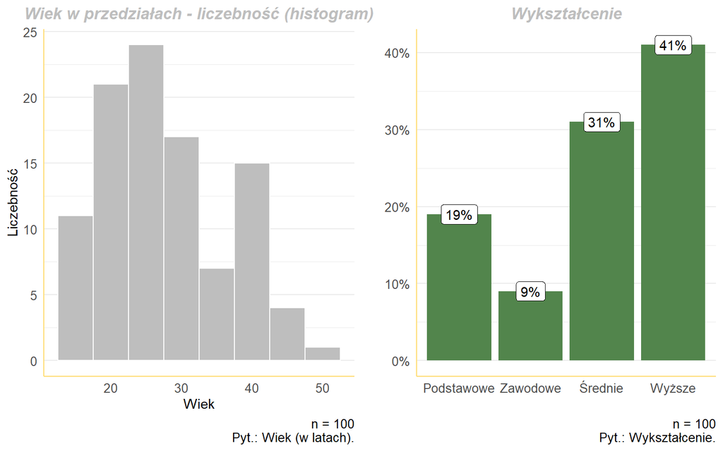

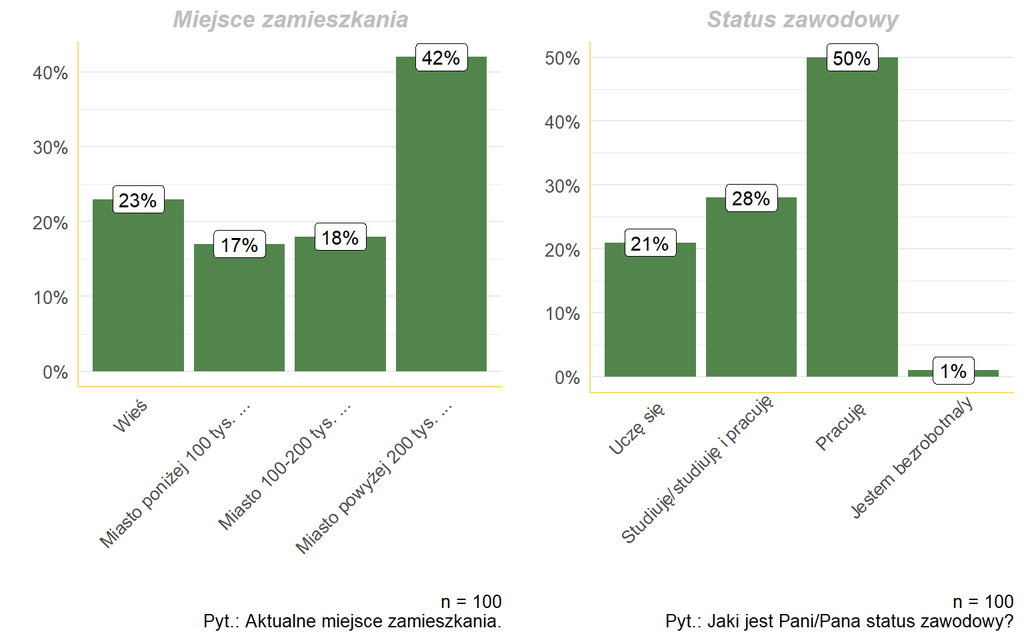

Najwięcej badanych mieszka w największych miastach (w badaniu rozumianych jako miasta o więcej niż 200 tys. mieszkańców), a także pracuje.

Widać, wiedząc, jaki jest rozkład wspomnianych zmiennych w populacji np. mieszkańców Polski, że próba nie odzwierciedla tej populacji, ale jakąś inną, której większość stanowią młodsze, dobrze wykształcone osoby z dużych miast, aktywne zawodowo.

## Spożywanie produktów z syropem glukozowo-fruktozowym

Jednym z pytań badawczych było, czy badani w ogóle spożywają produkty z syropem glukozowo-fruktozowym, jeśli tak, to jak często i czy starają się to spożycie ograniczać. Okazało się, że - co prawdopodobnie nie jest zaskakujące - respondenci w większości przypadków kupują produkty z tym składnikiem.

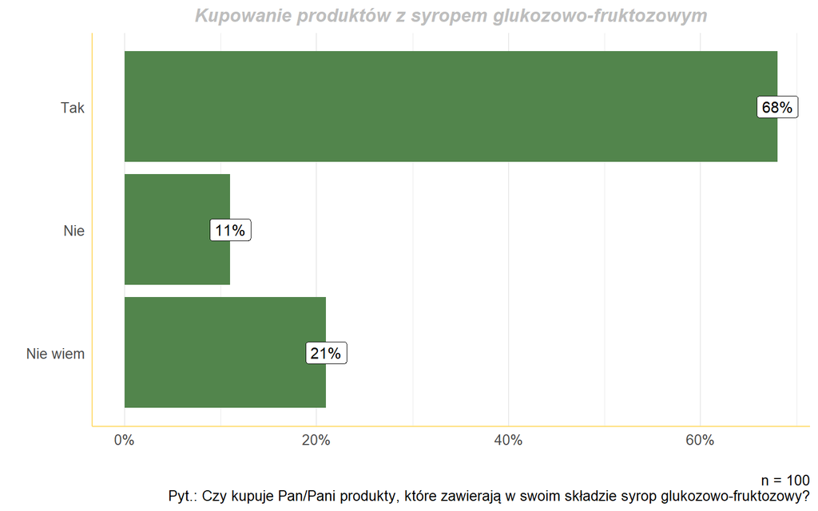

Warto odnotować spory udział odpowedzi “Nie wiem”, które dotykają innej nieco kwestii, tj. świadomości konsumenckiej i wiedzy, co będzie przedmiotem późniejszej analizy.

Wśród tych, którzy wiedzą, że kupują produkty z syropem glukozowo-fruktozowym, przeważają odpowiedzi wskazujące na napoje i słodycze jako te kategorie produktów, które najczęściej zawierają składnik będący przedmiotem tych studiów.

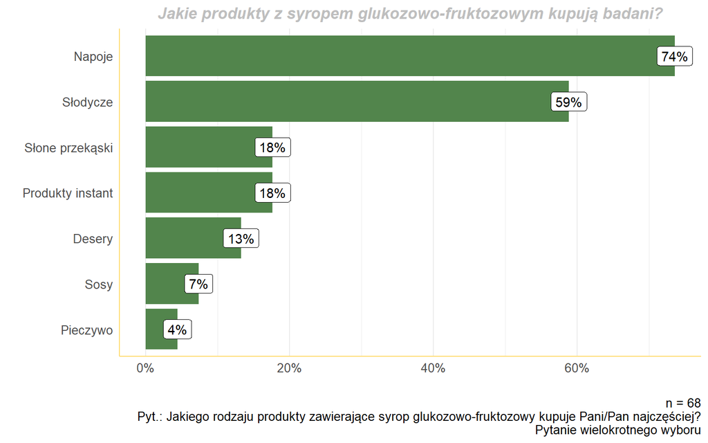

Zadano również pytanie o to, czy respondenci próbują ograniczać spożywanie produktów z syropem glukozowo-fruktozowym czy też nie. Wyniki wskazują, że więcej jest tych, którzy świadomie ograniczają udział tego składnika w diecie niż takich, którzy nie zastanawiają się nad tym:

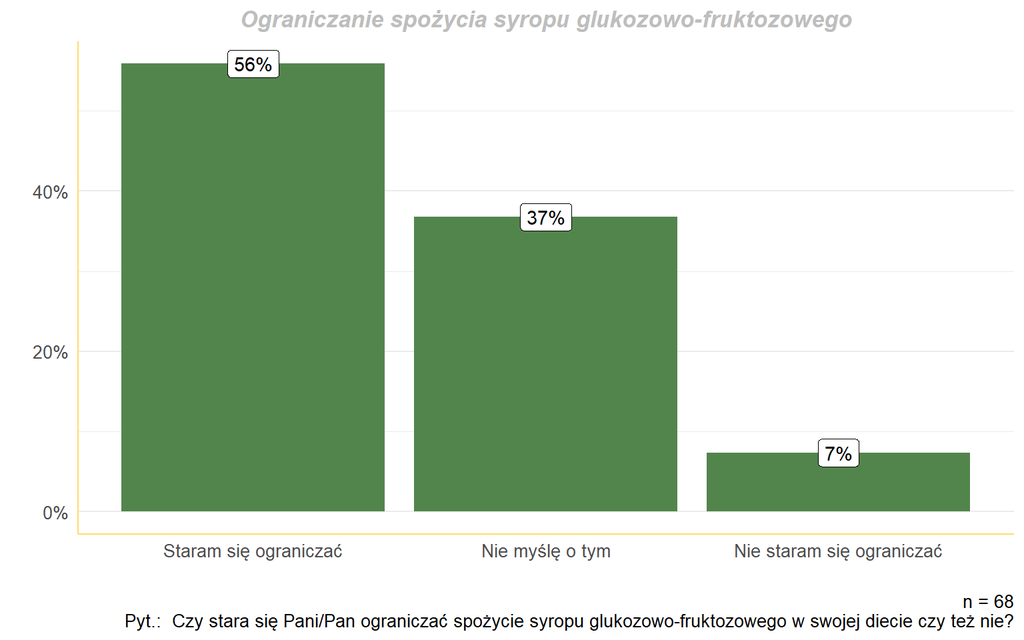

Jedną ze zmiennych niezależnych, niebędącą zmienną społeczno-demograficzną, było to, czy teraz lub kiedyś respondent jest lub był na diecie redukcyjnej lub innej niestandardowej. Założono, że osoby takie mogą w większym stopniu być świadomymi konsumentami produktów spożywczych. Badania pozwoliły to potwierdzić - zmienna ta różnicuje to, czy ktoś stara się świadomie ograniczać spożycie produktów z syropem glukozowo-fruktozowym.

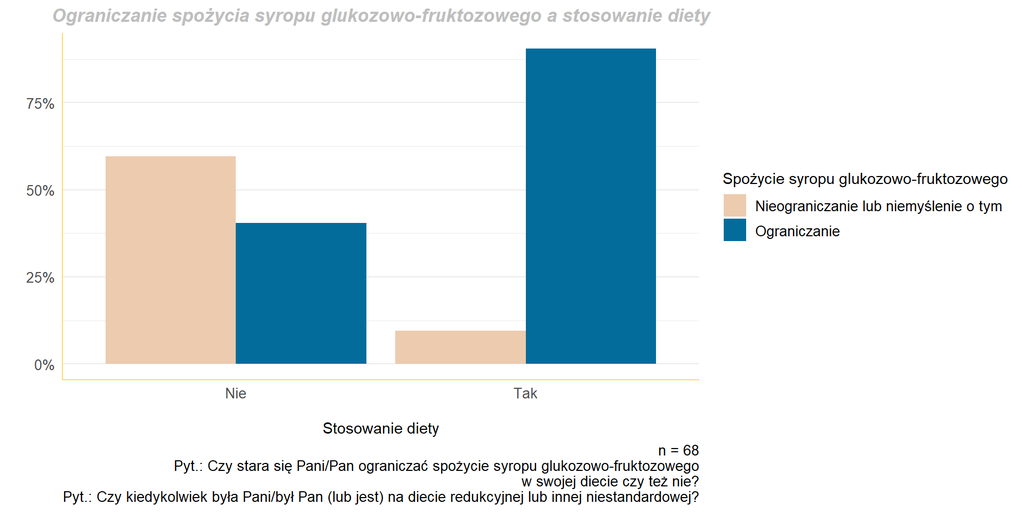

Świadome ograniczanie spożycia jest tu rozumiane jako przeciwstawne odpowiedzi do tych, które mówiły o niemyśleniu o tej kwestii lub nieograniczaniu spożycia syropu glukozowo-fruktozowego (te dwie kategorie zostały połączone). Ci respondenci, którzy kiedykolwiek byli na diecie redukcyjnej lub innej niestandardowej istotnie statystycznie (p < 0,01) częściej świadomie ograniczają spożycie syropu glukozowo-fruktozowego.

Podsumowując, badani w większości spożywają produkty z syropem glukozowo-fruktozowym, wśród których najczęściej pojawiają się słodycze i napoje, aczkolwiek deklarują jednocześnie to, że wiedzą, iż syrop ten jest niezdrowy, częściej starając się ograniczać jego spożycie niż niepodejmować świadomych działań.

## Czytanie etykiet

Zbadano dwie rzeczy, jeśli chodzi o czytanie etykiet przez respondentów - jak często w ogóle w ich domach weryfikuje się etykiety produktów spożywczych oraz, na którym miejscu zazwyczaj, w kupowanych przez nich produktach, znajduje się syrop glukozowo-fruktozowy, tj. czy jest to mniej więcej na początku listy składników, w środku czy na końcu.

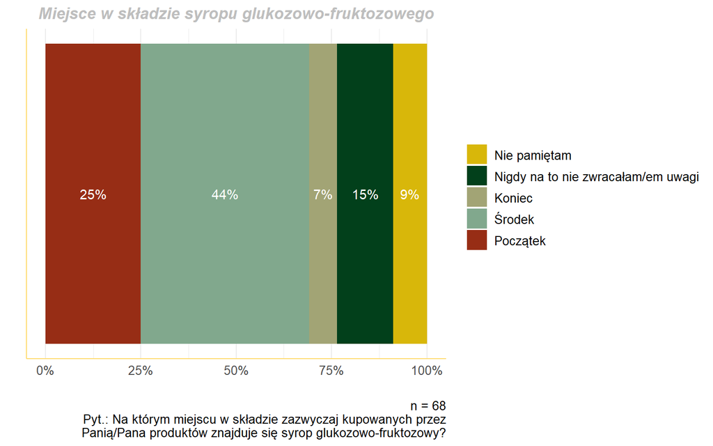

Zazwyczaj jest to środek listy składników. Co ciekawe, respondenci raczej nie mieli problemu z tym pytaniem (niewielki odsetek odpowiedzi “Nie pamiętam” oraz “Nigdy na to nie zwracałam/em uwagi”). Wydaje się to spójne z tym, że większość z nich w ogóle wie, czy spożywa syrop glukozowo-fruktozowy.

Pytanie o częstość weryfikowania składów produktów nie odnosiło się jedynie do zachowań respondenta, ale miało w zamierzeniu dotyczyć także jego najbliższego otoczenia, czyli domowników w ogóle. Wydawało się to szczególnie interesujące z tego punktu widzenia, że w badaniu chciano sprawdzić, jak fakt posiadania dziecka oraz ich wiek wpływa na rodziców ze względu na żywienie oraz wiedzę na temat żywienia.

Wiek dzieci wyznaczało pytanie o wiek najmłodszego dziecka, a w toku analizy wykluczono tych respondentów, których najmłodsze dziecko miało więcej niż 19 lat, zakładając, że dość prawodpodobne jest, iż wtedy dzieci przestają głównie mieszkać z rodzicami, a zatem uwzględnienie takich przypadków byłoby niezgodne z problemem badawczym, ponieważ w pewnym sensie objęłoby rodziców nieróżniących się od tych dorosłych, którzy w ogóle nie mają dzieci. Dane pokazały, że im dzieci stają się coraz starsze, etykiety rzadziej są weryfikowane (czytane).

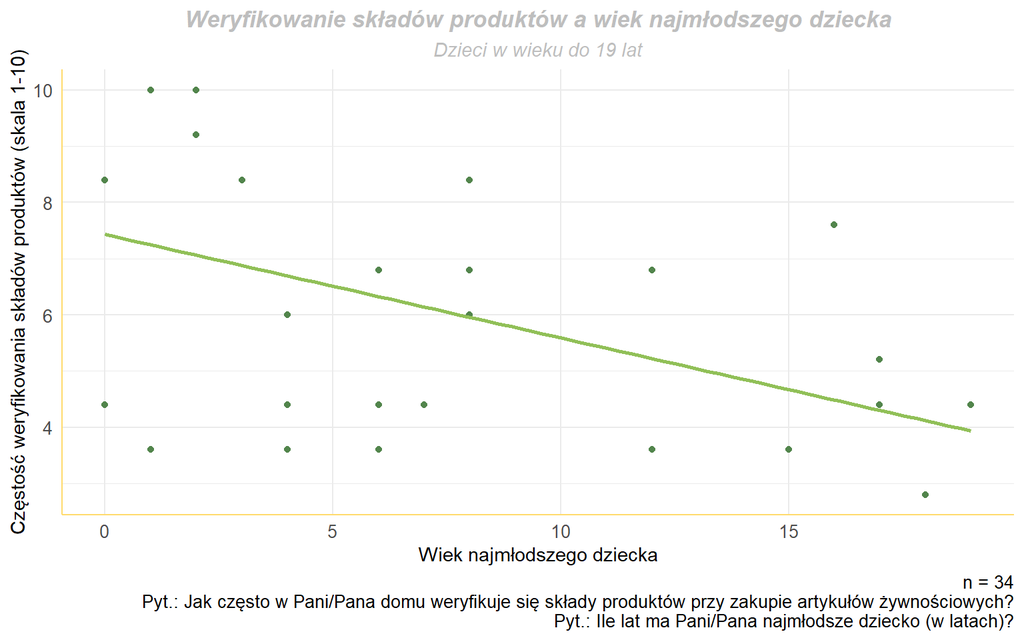

| Wartość korelacji | Istotność statystyczna | Metoda |
| --- | --- | --- |
| -0,46 | p < 0,01 | Współczynnik korelacji rang Spearmana |

Współczynnik korelacji wyniósł -0,46, jest więc umiarkowany.

Także w przypadku częstości weryfikowania składów produktów znaczenie okazał się mieć fakt, czy respondenci byli na diecie redukcyjnej lub innej niestandardowej. Jeśli tak - istotnie statystycznie (p < 0,01) częściej czytali etykiety:

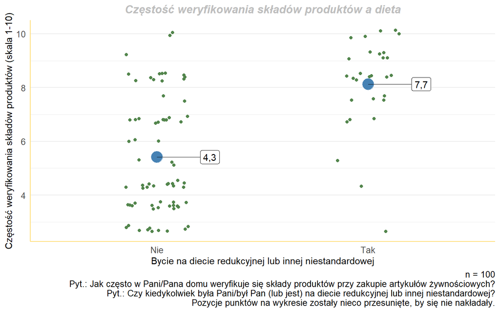

## Podsumowanie

Studia pokazały, że badani byli w dużym stopniu świadomymi konsumentami produktów spożywczych na przykładzie syropu glukozowo-fruktozowego: potrafili w większości powiedzieć, czy w ogóle kupują produkty z tym składnikiem, jakie najczęściej są to produkty i na którym miejscu w składzie ten składnik występuje. Zauważono, że ważną zmienną różnicująco świadome ograniczanie spożycia syropu glukozowo-fruktozowego jest to, czy ktoś był na diecie. Jeśli tak, większą uwagę przykłada do żywienia. Biorąc pod uwagę czytanie etykiet produktów w ogóle, a nie skupiając się tylko na syropie glukozowo-fruktozwym, badania pokazały również, że im ktoś ma młodsze dzieci, tym częściej w jego domu weryfikuje się składy produktów.